# 12_03.02

**NOTE: Before running this notebook, be sure to place your copy of RomeoAndJuliet.txt in the same folder as the notebook.**

## 12.3.2 Visualizing Word Frequencies with Word Clouds

- Open source [**`wordcloud` module’s**](https://github.com/amueller/word_cloud) **`WordCloud` class**
- Uses matplotlib under the hood

### Installing the wordcloud Module

- `conda install -c conda-forge wordcloud`
  - Windows users should **run the Anaconda Prompt as an Administrator**

### Loading the Text

```python
from pathlib import Path
```

```python
text = Path('RomeoAndJuliet.txt').read_text()
```

### Loading the Mask Image that Specifies the Word Cloud’s Shape

- `WordCloud` fills non-white areas of a mask image with text
- Load the mask using the **`imread` function** from the `imageio` module that comes with Anaconda

```python
import imageio
```

```python
mask_image = imageio.imread('mask_heart.png')
```

### Configuring the WordCloud Object

- 400-by-200 pixels, unless you specify **`width`** and **`height`**
- If you specify a mask image without `width` and `height`, `WordCloud` uses the image’s size
- `WordCloud` assigns **random colors** from a **color map**
- [Matplotlib’s named color maps](https://matplotlib.org/examples/color/colormaps_reference.html)
- [Complete list of `WordCloud`’s keyword arguments](http://amueller.github.io/word_cloud/generated/wordcloud.WordCloud.html)

```python
from wordcloud import WordCloud
```

```python
wordcloud = WordCloud(width=1000, height=1000,
    colormap='prism', mask=mask_image, background_color='white')
```

### Generating the Word Cloud

- `WordCloud`’s `generate` method receives the text to use in the word cloud as an argument and creates the word cloud, which it returns as a `WordCloud` object

```python
wordcloud = wordcloud.generate(text)
```

- **removes stop words** from the `text` argument, using the `wordcloud` module’s built-in stop-words list
- **calculates the word frequencies** for the remaining words
- **builds the cloud** with a **maximum of 200 words by default**, but can specify **`max_words` keyword argument**

### Saving the Word Cloud as an Image File

```python
wordcloud = wordcloud.to_file('RomeoAndJulietHeart.png')
```

### Generating a Word Cloud from a Dictionary

- If you have a dictionary of word counts, `WordCloud`’s **`fit_words` method** can create a word cloud from it, but does not remove the stop words from the dictionary

### Displaying the Image with Matplotlib

```python
%matplotlib inline
```

```python
import matplotlib.pyplot as plt
```

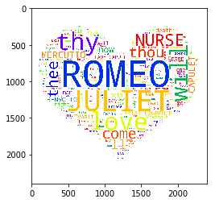

```python
plt.imshow(wordcloud)
```

[figure not shown]